# Regression Homework

David Coit

Fall 2019

```r
library(caret)
library(MASS)
library(ggplot2)
library(dplyr)
library(ggfortify)
library(elasticnet)

#Mauna Loa CO2 concentrations
data(airquality)
```

1. Split data into training and test set (75% in train set, 25% in test set)

```r
# set a random seed so results are the same across testing runs
set.seed(2718)
# use the createDataPartiion function to create an index
# for splitting the data set
train_index = createDataPartition(airquality$Temp, p = .75,
                                  list = FALSE,
                                  times = 1)
# split airquality into complementary subsets
train_regression = airquality[train_index,]
test_regression = airquality[-train_index,]
```

2. Create and fit a linear model to predict Temperature from Wind using the training set

```r
linear_regression <- train(Temp ~ Wind, data=train_regression, method = "lm")
summary(linear_regression)
```

```
##
## Call:
## lm(formula = .outcome ~ ., data = dat)
##
## Residuals:
##     Min      1Q  Median      3Q     Max
## -23.350  -5.727   1.650   6.149  19.271
##
## Coefficients:
##             Estimate Std. Error t value Pr(>|t|)
## (Intercept)  90.3458     2.2791   39.64  < 2e-16 ***
## Wind         -1.2494     0.2132   -5.86 4.51e-08 ***
## ---
## Signif. codes:  0 '***' 0.001 '**' 0.01 '*' 0.05 '.' 0.1 ' ' 1
##
## Residual standard error: 8.638 on 115 degrees of freedom
## Multiple R-squared:  0.2299, Adjusted R-squared:  0.2232
## F-statistic: 34.34 on 1 and 115 DF,  p-value: 4.506e-08
```

3. Vizualize how your model performed on the train data by plotting the regression line on top of the train data points.

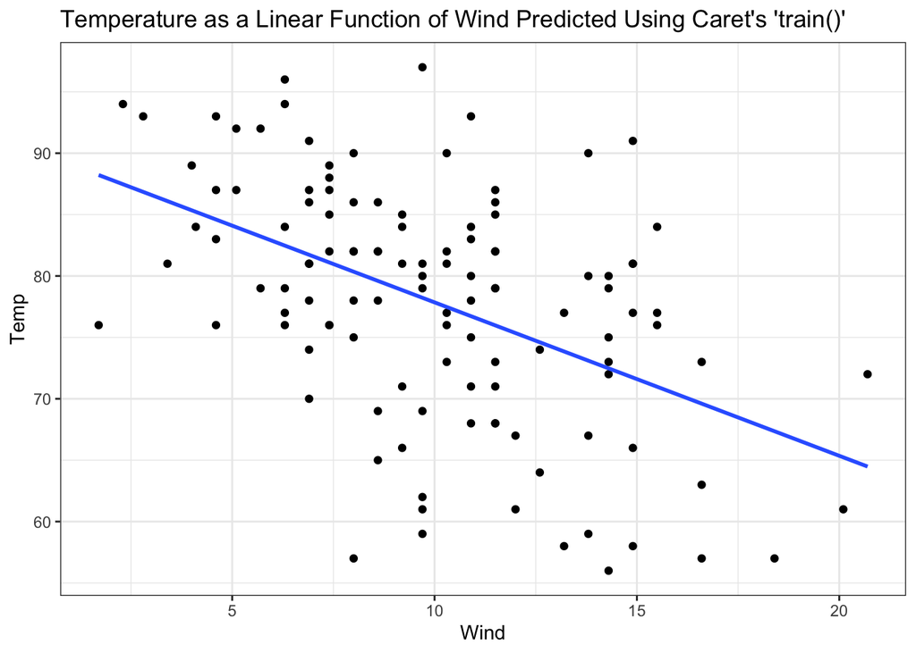

```r
ggplot() +
  geom_point(data = train_regression,
             aes(x=Wind, y=Temp)) +
  geom_smooth(data = train_regression,
              aes(x=Wind,y=predict(linear_regression, newdata = train_regression))) +
  theme_bw() +
  ggtitle("Temperature as a Linear Function of Wind Predicted Using Caret's 'train()'")
```

```r
# Use the cor.test() function to test the correlation between
# test_regression set Wind values and the Wind values predicted by regression

# test correlation between test set Wind values and linear regression applied to test set
# ie between actual and predicted
correlation <- cor.test(test_regression$Wind, predict(linear_regression, newdata = test_regression),
                    method = "pearson")
correlation
```

```
##
##  Pearson's product-moment correlation
##
## data:  test_regression$Wind and predict(linear_regression, newdata = test_regression)
## t = -Inf, df = 34, p-value < 2.2e-16
## alternative hypothesis: true correlation is not equal to 0
## 95 percent confidence interval:
##  -1 -1
## sample estimates:
## cor
##  -1
```

**The correlation is strong, with a value so close to -1 that R rounds off both the sample estimate and the confidence interval boundaries.**

4. Explore how the model performs on the test data. For Linear Regression:
- The residuals should be close to zero.
- There should be equal variance around the regression line (homoscedasticity).
- Residuals should be normally distributed.
- Independent variables and residuals should not be correlated.

4 a) See how the model performs on the test data

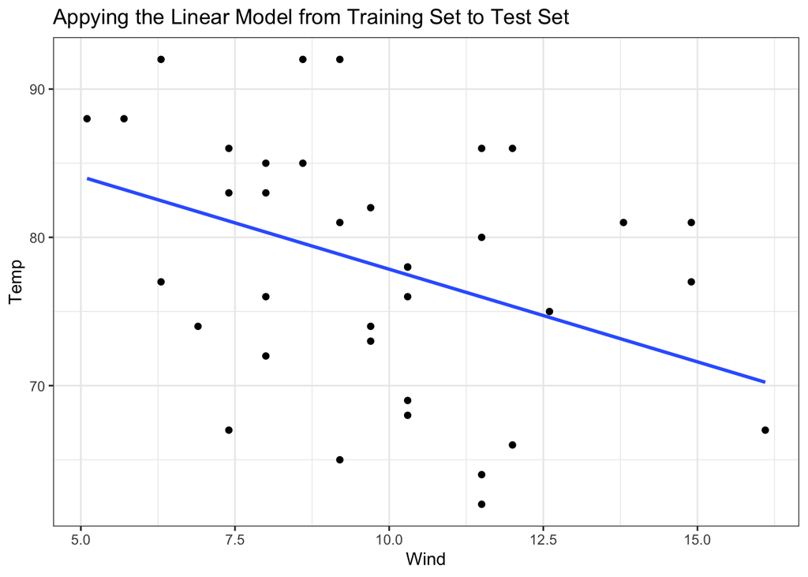

```r
linear_prediction <- predict(linear_regression, newdata=test_regression['Wind'])

ggplot() +
  geom_point(data = test_regression,
             aes(x=Wind, y=Temp)) +
  # geom_smooth(data = test_regression,
  #             aes(x=Wind,y=predict(linear_regression, newdata = test_regression))) +
  geom_smooth(data = test_regression,
              aes(x=Wind,y=linear_prediction)) +
  theme_bw() +
  ggtitle("Appying the Linear Model from Training Set to Test Set")
```

```r
#summary(linear_prediction)
```

4 b) Look at the residuals. Are they close to zero?

```r
#look at the median residual value. Close to zero is best
linear_prediction <- predict(linear_regression, newdata=train_regression['Wind'])
res <- c()

summary(residuals(linear_regression))
```

```
##    Min. 1st Qu.  Median    Mean 3rd Qu.    Max.
## -23.350  -5.727   1.650   0.000   6.149  19.271
```

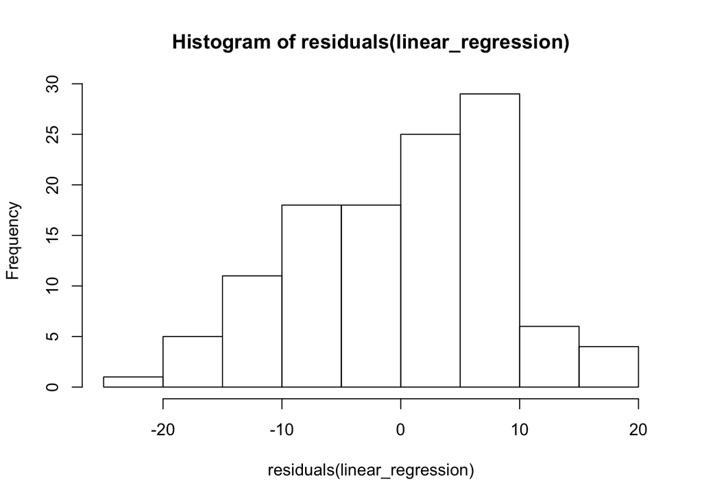

```r
hist(residuals(linear_regression))
```

**The mean of the residuals is exactly 0 and the median is fairly close at 1.65, but when we plot a histogram of the residuals we can see that there are several values with an absolute value greater than 10. Also, the distribution appears to be skewed.**

4 c) Plot predicted temperature vs observed temperature. A strong model should show a strong correlation

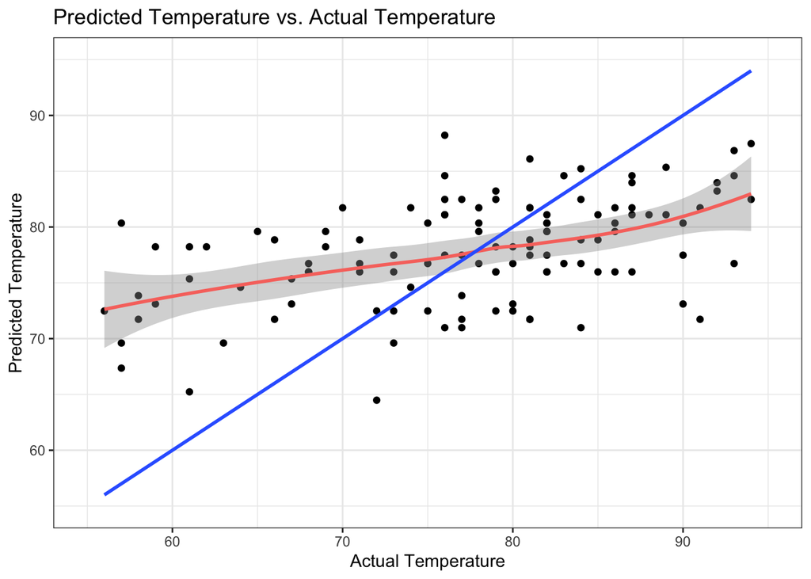

```r
ggplot(data = train_regression) +
  # Plot scatter of predicted vs. true temperatures
  geom_point(aes(x=Temp, y=predict(linear_regression, newdata = train_regression))) +
  # Plot smooth trend line of predicted v. true temp
  geom_smooth(aes(x=Temp, y=predict(linear_regression, newdata = train_regression), color = 'r')) +
  # Plot identity function as reference
  geom_smooth(aes(x=Temp, y=Temp)) +
  theme_bw() +
  xlim(55,95) +
  ylim(55,95) +
  xlab("Actual Temperature") +
  ylab("Predicted Temperature") +
  ggtitle("Predicted Temperature vs. Actual Temperature") +
  theme(legend.position = 'none')
```

```r
  cor.test(predict(linear_regression, newdata = test_regression), test_regression$Wind)
```

```
##
##  Pearson's product-moment correlation
##
## data:  predict(linear_regression, newdata = test_regression) and test_regression$Wind
## t = -Inf, df = 34, p-value < 2.2e-16
## alternative hypothesis: true correlation is not equal to 0
## 95 percent confidence interval:
##  -1 -1
## sample estimates:
## cor
##  -1
```

4 d) Visualize the predicted values in relation to the real data points. Look for homoscedasticity

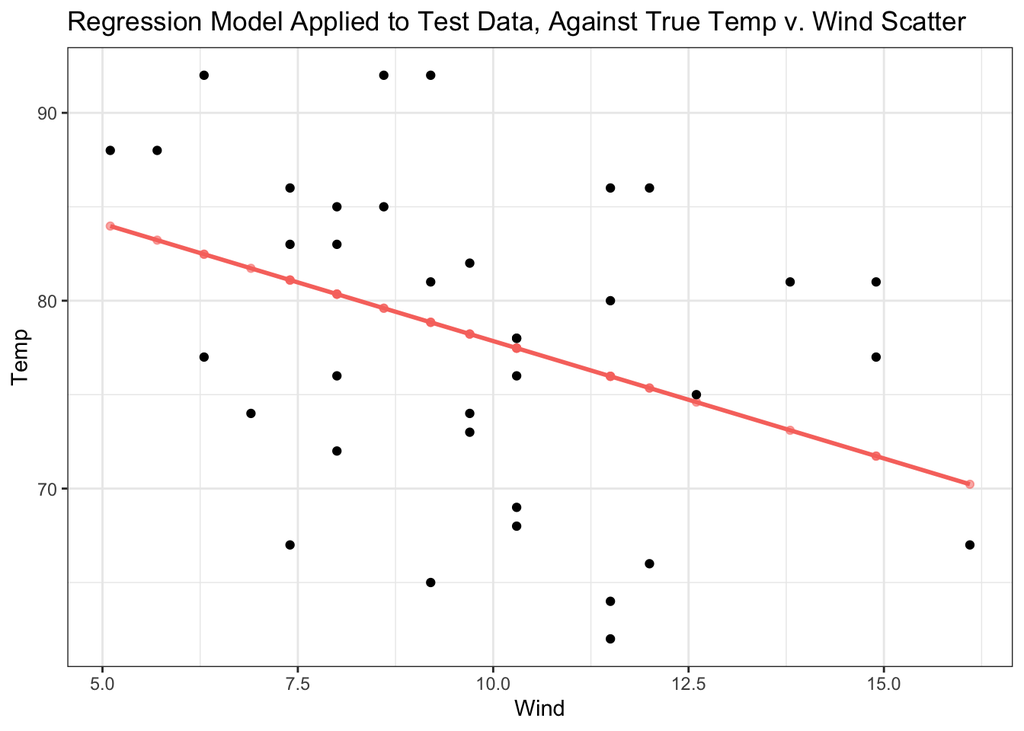

```r
#plot the regression line on the predicted values
ggplot(data = test_regression) +
  geom_point(aes(x=Wind, y=predict(linear_regression, newdata = test_regression), color = 'r', alpha=0.8)) +
  geom_smooth(aes(x=Wind, y=predict(linear_regression, newdata = test_regression), color='r', alpha=0.8)) +
  geom_point(aes(x=Wind, y=Temp)) +
  theme_bw() +
  ggtitle("Regression Model Applied to Test Data, Against True Temp v. Wind Scatter ")  +
  theme(legend.position = "none") +
  ylab("Temp")
```

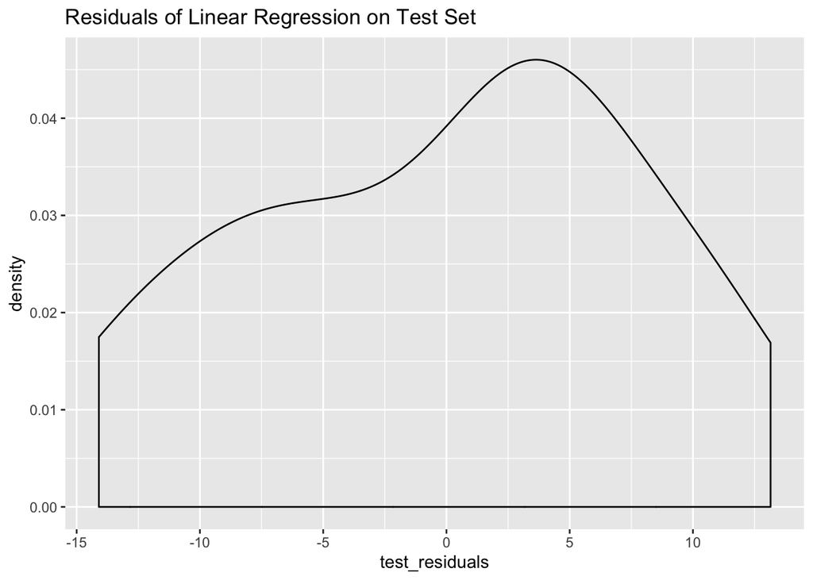

```r
# Create vector of residuals, test Temp - predicted test Temp
test_residuals = test_regression$Temp - predict(linear_regression, newdata = test_regression)

# Plot density of model residuals from test set
ggplot() +
  geom_density(aes(test_residuals)) +
  ggtitle("Residuals of Linear Regression on Test Set")
```

```r
# print stats on residuals
summary(test_residuals)
```

```
##      Min.   1st Qu.    Median      Mean   3rd Qu.      Max.
## -14.10002  -6.03698   1.21166  -0.09442   4.99267  13.14896
```

```r
shapiro.test(test_residuals)
```

```
##
##  Shapiro-Wilk normality test
##
## data:  test_residuals
## W = 0.95649, p-value = 0.1672
```

```r
# Test for homoscedasticity, ie are

cor.test(test_regression$Wind, test_residuals)
```

```
##
##  Pearson's product-moment correlation
##
## data:  test_regression$Wind and test_residuals
## t = 0.28132, df = 34, p-value = 0.7802
## alternative hypothesis: true correlation is not equal to 0
## 95 percent confidence interval:
##  -0.2848561  0.3708539
## sample estimates:
##        cor
## 0.04818947
```

**The estimate of correlation of the true values and the residuals of the model application to the test set is very low, at ~0.05. The high p-value of ~0.8 means we certainly cannot reject the hypothese that the true correlation between the independent variable and the residuals is 0.**

4 e) Residuals should be normally distributed. Plot the density of the residuals

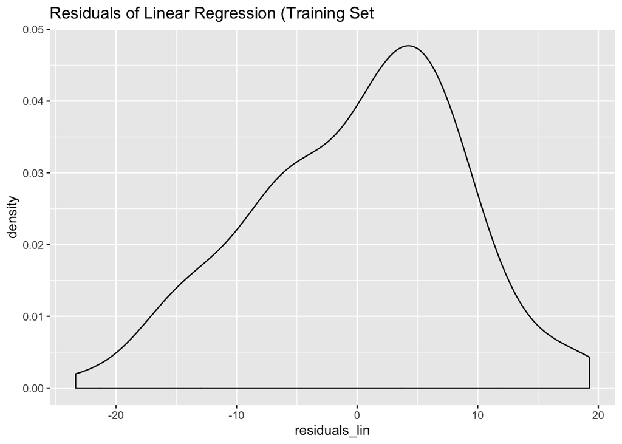

```r
# Looking at residuals from the regression on the training set
residuals_lin <- residuals(linear_regression)

# Plot density of residuals
ggplot() +
  geom_density(aes(residuals_lin)) +
  ggtitle("Residuals of Linear Regression (Training Set")
```

```r
# Test residuals for normality
summary(residuals_lin)
```

```
##    Min. 1st Qu.  Median    Mean 3rd Qu.    Max.
## -23.350  -5.727   1.650   0.000   6.149  19.271
```

```r
shapiro.test(residuals_lin)
```

```
##
##  Shapiro-Wilk normality test
##
## data:  residuals_lin
## W = 0.98441, p-value = 0.1951
```

4 f) Independent variables and residuals should not be correlated

```r
# Test correlation between Wind values and the residuals of the linear model

cor.test(train_regression$Wind, resid(linear_regression))
```

```
##
##  Pearson's product-moment correlation
##
## data:  train_regression$Wind and resid(linear_regression)
## t = 1.6648e-15, df = 115, p-value = 1
## alternative hypothesis: true correlation is not equal to 0
## 95 percent confidence interval:
##  -0.181533  0.181533
## sample estimates:
##          cor
## 1.552478e-16
```

**Here the correlation is extremely close to zero, being on the order of 10^-16. The p-value of the test is so close to 1 that R rounds it off, strongly indicating we cannot reject the null hypothesis that the correlation is equal to 0.**

### Linear Regression with Regularization

5. Create a linear model using L1 or L2 regularization to predict Temperature from Wind and Month variables. Plot your predicted values and the real Y values on the same plot.

```r
#library(rqPen)
ridge_linear_regression = train(Temp ~ Wind + Month, data=train_regression, method = "ridge")
lasso_linear_regression = train(Temp ~ Wind + Month, data=train_regression, method = "lasso")

#linear_regression <- train(Temp ~ Wind, data=train_regression, method = "bridge")
summary(ridge_linear_regression)
```

```
##             Length Class      Mode
## call        4      -none-     call
## actions     3      -none-     list
## allset      2      -none-     numeric
## beta.pure   6      -none-     numeric
## vn          2      -none-     character
## mu          1      -none-     numeric
## normx       2      -none-     numeric
## meanx       2      -none-     numeric
## lambda      1      -none-     numeric
## L1norm      3      -none-     numeric
## penalty     3      -none-     numeric
## df          3      -none-     numeric
## Cp          3      -none-     numeric
## sigma2      1      -none-     numeric
## xNames      2      -none-     character
## problemType 1      -none-     character
## tuneValue   1      data.frame list
## obsLevels   1      -none-     logical
## param       0      -none-     list
```

```r
summary(lasso_linear_regression)
```

```
##             Length Class      Mode
## call        4      -none-     call
## actions     3      -none-     list
## allset      2      -none-     numeric
## beta.pure   6      -none-     numeric
## vn          2      -none-     character
## mu          1      -none-     numeric
## normx       2      -none-     numeric
## meanx       2      -none-     numeric
## lambda      1      -none-     numeric
## L1norm      3      -none-     numeric
## penalty     3      -none-     numeric
## df          3      -none-     numeric
## Cp          3      -none-     numeric
## sigma2      1      -none-     numeric
## xNames      2      -none-     character
## problemType 1      -none-     character
## tuneValue   1      data.frame list
## obsLevels   1      -none-     logical
## param       0      -none-     list
```

[figure not shown]

```r
ggplot(data=test_regression) +
   geom_point(aes(x=Wind, y=Temp)) +
   geom_point(aes(x=Wind, y=predict(ridge_linear_regression, newdata = test_regression), color = 'r', alpha=0.5)) +
   geom_point(aes(x=Wind, y=predict(lasso_linear_regression, newdata = test_regression), color = 'b', alpha=0.5)) +
   theme_bw() +
   theme(legend.position = "none") +
   ggtitle("Lasso (blue) and Ridge Regressions (red) vs. True Values (black) \n with Wind and Month as Predictor Variables for Temperature")
```